# Econ 320: Python Assignment 3

## Package setup

```python
# Import necessary packages here

import numpy as np
import pandas as pd
import matplotlib.pyplot as plt
import seaborn as sns
import wooldridge as woo
import scipy.stats as stats
from IPython.core.display import HTML
import statsmodels.formula.api as smf
from matplotlib.lines import Line2D
from stargazer.stargazer import Stargazer
from matplotlib.patches import Patch

# Code to print path of current working directory
import os
print(os.getcwd())
```

```
d:\school work\2025 Spring\Econ 320\Econ320Lab\Assignment 3
```

# Question 1

The dataset *ps2q1.dta* contains data on 177 chief executive officers and can be used to examine the effects of firm performance on CEO salary.

i. Estimate a model relating the CEO's annual salary, the dependent variable, to firm sales, the independent variable.

$$salary_i= \beta_0 + \beta_1sales_i +u_i$$

What is your estimate of the intercept and the slope? Don't forget the units, which you can find using the "describe" command. Interpret these estimates, providing an intuitive description that a person who has not taken econometrics can understand. Does your result make economic sense?

```python
data = pd.read_stata("ps2q1.dta")
print(data.info())
```

```
<class 'pandas.core.frame.DataFrame'>
RangeIndex: 177 entries, 0 to 176
Data columns (total 12 columns):
 #   Column    Non-Null Count  Dtype
---  ------    --------------  -----
 0   salary    177 non-null    int16
 1   age       177 non-null    int8
 2   college   177 non-null    int8
 3   grad      177 non-null    int8
 4   comten    177 non-null    int8
 5   ceoten    177 non-null    int8
 6   sales     177 non-null    float32
 7   profits   177 non-null    int16
 8   mktval    177 non-null    float32
 9   comtensq  177 non-null    int16
 10  ceotensq  177 non-null    int16
 11  profmarg  177 non-null    float32
dtypes: float32(3), int16(4), int8(5)
memory usage: 4.5 KB
None
```

salary: Measured in thousands of dollars.  
sales: Measured in millions of dollars.

```python
model = smf.ols(formula='salary ~ sales', data=data).fit()
print(model.summary())
```

```
                            OLS Regression Results
==============================================================================
Dep. Variable:                 salary   R-squared:                       0.438
Model:                            OLS   Adj. R-squared:                  0.435
Method:                 Least Squares   F-statistic:                     136.6
Date:                Sat, 22 Mar 2025   Prob (F-statistic):           1.08e-23
Time:                        18:04:10   Log-Likelihood:                -1456.2
No. Observations:                 177   AIC:                             2916.
Df Residuals:                     175   BIC:                             2923.
Df Model:                           1
Covariance Type:            nonrobust
==============================================================================
                 coef    std err          t      P>|t|      [0.025      0.975]
------------------------------------------------------------------------------
Intercept    474.2893     79.154      5.992      0.000     318.071     630.508
sales          0.1317      0.011     11.687      0.000       0.109       0.154
==============================================================================
Omnibus:                      187.510   Durbin-Watson:                   2.086
Prob(Omnibus):                  0.000   Jarque-Bera (JB):             8601.497
Skew:                           3.774   Prob(JB):                         0.00
Kurtosis:                      36.307   Cond. No.                     8.12e+03
==============================================================================

Notes:
[1] Standard Errors assume that the covariance matrix of the errors is correctly specified.
[2] The condition number is large, 8.12e+03. This might indicate that there are
strong multicollinearity or other numerical problems.
```

ii. Calculate the mean of $salary$ and $sales$. Use these values to prove that the predicted regression line estimated in regression (1) goes through the means of $salary$ and $sales$.

```
          salary      sales
count    177.000    177.000
mean     939.192   3529.463
std     1211.342   6088.654
min      100.000     29.000
25%      471.000    561.000
50%      707.000   1400.000
75%     1119.000   3500.000
max    15000.000  51300.000
Mean of sales: 3529.463
Mean of salary: 939.192
Estimated salary for mean sales: 939.192
Therefore, the averages of salary and sales are on the estimated regression line.
```

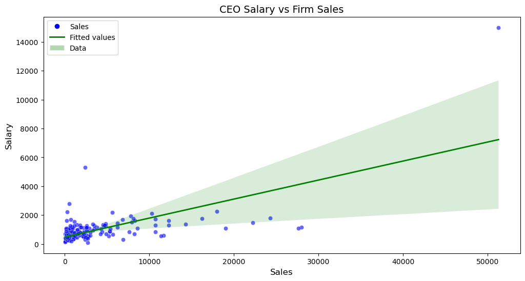

```python
summary_table = data[['salary', 'sales']].describe().round(3)
print(summary_table)
m_salary = data['salary'].mean()
m_sales = data['sales'].mean()
intercept = model.params['Intercept']
slope = model.params['sales']
predicted_salary_at_mean_sales = intercept + slope * m_sales
print(f"Mean of sales: {m_sales:.3f} ")
print(f"Mean of salary: {m_salary:.3f} ")
print(f"Estimated salary for mean sales: {predicted_salary_at_mean_sales:.3f} ")
if round(predicted_salary_at_mean_sales, 3) == round(m_salary, 3):
    print("Therefore, the averages of salary and sales are on the estimated regression line.")
else:
    print("The averages of salary and sales are not on the estimated regression line.")

plt.figure(figsize=(12, 6))
sns.scatterplot(x=data['sales'], y=data['salary'], label="Data", color="blue", alpha=0.6)
sns.regplot(x=data['sales'], y=data['salary'], scatter=False, label="Fitted values", color="green", line_kws={"linewidth": 2}, ci=95)
plt.xlabel("Sales", fontsize=12)
plt.ylabel("Salary", fontsize=12)
plt.title("CEO Salary vs Firm Sales", fontsize=14)
legend_elements = [
    Line2D([0], [0], marker='o', color='w', label='Sales', markerfacecolor='blue', markersize=8),
    Line2D([0], [0], color='green', label='Fitted values', linewidth=2),
    Patch(facecolor='green', edgecolor='w', alpha=0.3, label='Data')
]
plt.legend(handles=legend_elements, loc="upper left")
plt.show()
```

iii. The data entry expert contacts you very concerned about the data they gave you. They realized there was a typo. Replace the value of salary to be 2500 if salary is equal to 15000. Estimate regression (1) with this change. Save the predicted values of salary (). Show a graph with the scatter plot of salary and sales and the predicted regression line of question 1.1 and question 1.4. Discuss these results.

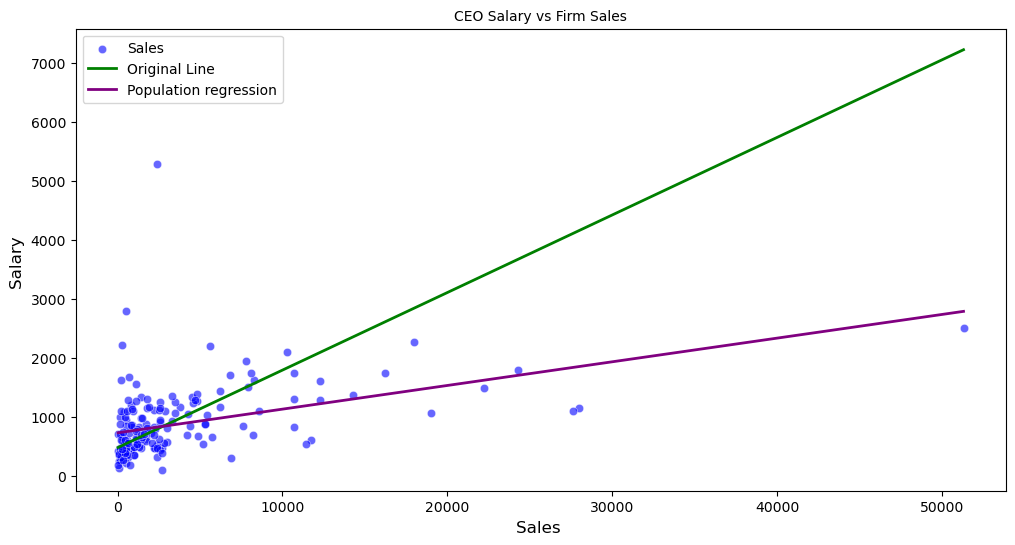

```python
data.loc[data['salary'] == 15000, 'salary'] = 2500
model_corrected = smf.ols(formula='salary ~ sales', data=data).fit()
data['predicted_salary_corrected'] = model_corrected.predict(data)
data['predicted_salary_original'] = model.predict(data)
plt.figure(figsize=(12, 6))
sns.scatterplot(x=data['sales'], y=data['salary'], label="Sales", color="blue", alpha=0.6)
sns.lineplot(x=data['sales'], y=data['predicted_salary_original'], label="Original Line", color="green", linewidth=2)
sns.lineplot(x=data['sales'], y=data['predicted_salary_corrected'], label="Population regression", color="purple", linewidth=2)
plt.xlabel("Sales ", fontsize=12)
plt.ylabel("Salary ", fontsize=12)
plt.title("CEO Salary vs Firm Sales", fontsize=10)
plt.legend()
plt.show()
```

iv. A colleague presented a histogram displaying the distribution of salary and argued that no one could draw any conclusions from a regression using this variable. He correctly points out that regression lines fit through data better when the data is spread across the range of the variable’s possible values. Your colleague wants to use the natural **log of salary** and the natural **log ofbsales** in the model as this function can help to spread out the values of salary and sales. Create the natural logarithm of salary, lnsalary, and the natural logarithm of sales, lnsales. Show the histograms of salary, lnsalary, sales, and lnsales. Discuss whether you think your colleague’s method of spreading the data worked. Estimate the following model:

$lnsalaryi=\gamma_0+\gamma_1lnsalesi+vi$

Then show the regression plot for this new model

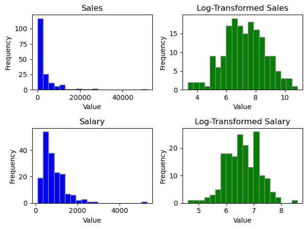

```python
# Create the variables lnsales and lnsalary in the dataset
data['lnsales'] = np.log(data['sales'])
data['lnsalary'] = np.log(data['salary'])

# Fora graph like this you need to create the grid space for plots
#define grid of plots
fig, axs = plt.subplots(nrows=2, ncols=2)

#create histograms
axs[0, 0].hist(data['sales'], edgecolor='gray', bins=20, color='blue')
axs[0, 1].hist(data['lnsales'], edgecolor='gray', bins=20, color='green')
axs[1, 0].hist(data['salary'], edgecolor='gray', bins=20, color='blue')
axs[1, 1].hist(data['lnsalary'], edgecolor='gray', bins=20, color='green')
axs[0, 0].set_title('Sales')
axs[0, 1].set_title('Log-Transformed Sales')
axs[1, 0].set_title('Salary')
axs[1, 1].set_title('Log-Transformed Salary')
for ax in axs.flat:
    ax.set_xlabel('Value')
    ax.set_ylabel('Frequency')


#add title to each histogram
axs[0,0].set_title('Sales');
axs[0,1].set_title('Log-Transformed Sales');

#add title to each histogram
axs[1,0].set_title('Salary');
axs[1,1].set_title('Log-Transformed Salary');

plt.tight_layout()
plt.show()
```

```
                            OLS Regression Results
==============================================================================
Dep. Variable:               lnsalary   R-squared:                       0.284
Model:                            OLS   Adj. R-squared:                  0.280
Method:                 Least Squares   F-statistic:                     69.45
Date:                Sat, 22 Mar 2025   Prob (F-statistic):           2.22e-14
Time:                        18:04:11   Log-Likelihood:                -133.09
No. Observations:                 177   AIC:                             270.2
Df Residuals:                     175   BIC:                             276.5
Df Model:                           1
Covariance Type:            nonrobust
==============================================================================
                 coef    std err          t      P>|t|      [0.025      0.975]
------------------------------------------------------------------------------
Intercept      4.9469      0.200     24.703      0.000       4.552       5.342
lnsales        0.2264      0.027      8.333      0.000       0.173       0.280
==============================================================================
Omnibus:                       12.470   Durbin-Watson:                   2.090
Prob(Omnibus):                  0.002   Jarque-Bera (JB):               33.002
Skew:                           0.060   Prob(JB):                     6.82e-08
Kurtosis:                       5.112   Cond. No.                         38.7
==============================================================================

Notes:
[1] Standard Errors assume that the covariance matrix of the errors is correctly specified.
```

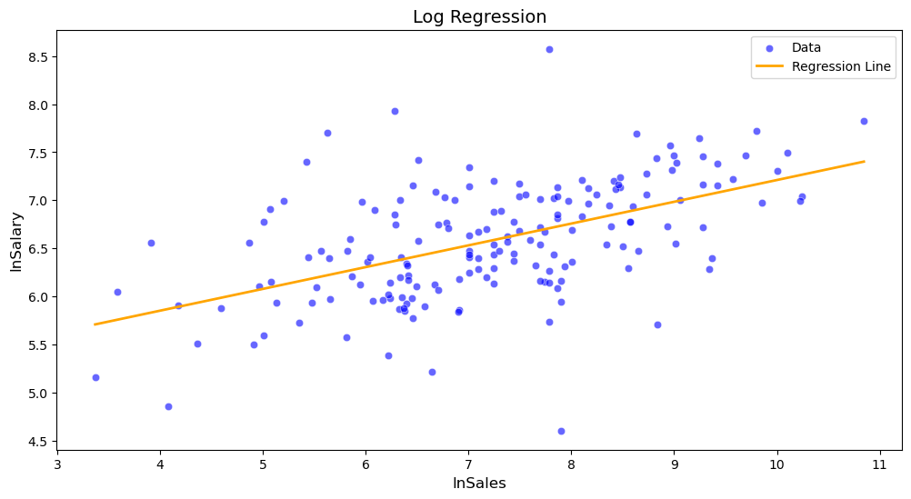

```python
# do the regression plot here.
log_model = smf.ols(formula='lnsalary ~ lnsales', data=data).fit()
print(log_model.summary())
plt.figure(figsize=(12, 6))
sns.scatterplot(x=data['lnsales'], y=data['lnsalary'], label="Data", color="blue", alpha=0.6)
sns.lineplot(x=data['lnsales'], y=log_model.predict(data), label="Regression Line", color="orange", linewidth=2)
plt.xlabel("lnSales", fontsize=12)
plt.ylabel("lnSalary", fontsize=12)
plt.title("Log Regression", fontsize=14)
plt.legend()
plt.show()
```

# Question 2

Use the dataset ATTEND for this exercise, and the handouts to work on these questions. Wooldridge data sets here: http://fmwww.bc.edu/ec-p/data/wooldridge/datasets.list.html

i. Generate a table that shows the minimum, maximum, and average values for the following variables in the attend dataset:  
Percent classes attended  
Cumulative GPA prior to term  
ACT score  
Using two different methods. Round off all calculations to 3 decimal points. (Refer to week 3 module)

```python
# Load dataset attend from wooldridge, call it attend.
attend = woo.data('attend')
# Method 1: Use .agg() to calculate, call it tablestats.
columns = ['atndrte', 'priGPA', 'ACT']
t = attend[columns].agg(['mean', 'min', 'max']).round(3)
print("Table using .agg():")
print(t)
```

```
Table using .agg():
      atndrte  priGPA    ACT
mean    81.71   2.587  22.51
min      6.25   0.857  13.00
max    100.00   3.930  32.00
```

```python
# Method 2: Use .describe() to calculate.
t2 = attend[columns].describe().round(3)
print("Table using .describe():")
print(t2)
```

```
Table using .describe():
       atndrte   priGPA      ACT
count  680.000  680.000  680.000
mean    81.710    2.587   22.510
std     17.047    0.545    3.491
min      6.250    0.857   13.000
25%     75.000    2.190   20.000
50%     87.500    2.560   22.000
75%     93.750    2.943   25.000
max    100.000    3.930   32.000
```

ii. Estimate the following model:

$$atndrte = \beta_0 + \beta_1 priGPA + \beta_2 ACT + u$$

Show results in an stargazer table. (Refer to output presentation handout)

```python
# Estimate log-level model, call it mc4.
# Fit your regression using .fit().
# Print results using summary:
mc4 = smf.ols(formula='atndrte ~ priGPA + ACT', data=attend).fit()
st = Stargazer([mc4])
HTML(st.render_html())
```

|  | *Dependent variable: atndrte* |
| --- | --- |
|  | (1) |
| ACT | -1.717*** |
|  | (0.169) |
| Intercept | 75.700*** |
|  | (3.884) |
| priGPA | 17.261*** |
|  | (1.083) |
| Observations | 680 |
| R<sup>2</sup> | 0.291 |
| Adjusted R<sup>2</sup> | 0.288 |
| Residual Std. Error | 14.379 (df=677) |
| F Statistic | 138.651*** (df=2; 677) |
| Note: | *p<0.1; **p<0.05; ***p<0.01 |

iii. Calculate and print the average of predicted value of percent classes attended ( $\hat{atndrte}$ ) and the predicted value. Round to 5 decimal points and compare results. (Refer to week 5 module)

> Note that these two are different coding-wise. The first method is the mean of the prediction, and the second is the prediction of the mean

```python
attend['predicted_atndrte'] = mc4.predict(attend)
# Print the mean of the prediction
m_predicted = attend['predicted_atndrte'].mean()
print(f"Model1 \n Average predicted attendance rate is \n mean of yhat= {m_predicted:.5f}")
# Find the prediction of the mean
m_priGPA = attend['priGPA'].mean()
m_ACT = attend['ACT'].mean()
predicted_mean = mc4.params['Intercept'] + mc4.params['priGPA'] * m_priGPA + mc4.params['ACT'] * m_ACT
# Print the prediction of the mean
print(f"Model1 \n Predicted attendance rate for average GPA and ACT is \n yhat of mean x=  {predicted_mean:.5f}")
```

```
Model1
 Average predicted attendance rate is
 mean of yhat= 81.70956
Model1
 Predicted attendance rate for average GPA and ACT is
 yhat of mean x=  81.70956
```

We can observe that these 2 values are the same :)!

iv. What is the predicted `atndrte` if `priGPA`= 3.65 and `ACT`= 20? What is the predicted difference in attendance rates between this and the the average $\hat{atndrte}$ above? (Refer to week 3 and 4 module)

In this case, do not use the `.predict()` function for your code. Instead, retrieve the coeffients and calculate the equation.
$$atndrte = \hat\beta_0 + \hat\beta_1 3.65 + \hat\beta_2 20 + u$$

```python
# Calculate the mean of the prediction, call this yhat1.
yhat1 = attend['predicted_atndrte'].mean()
# Calculate predicted atndrte for 3.65 GPA and 20 ACT using the above equation, call this yhat2.
yhat2 = mc4.params['Intercept'] + mc4.params['priGPA'] * 3.65 + mc4.params['ACT'] * 20
# Print yhat2 and round to 3 decimal places, call this yhat.
print(f"yhat = {yhat2:.3f}")
# Print the difference between yhat2 and yhat1, call this difference.
difference = yhat2 - yhat1
print(f"Difference = {difference:.3f}")
```

```
yhat = 104.371
Difference = 22.661
```

v. Run two more models: one only for freshmen and another only for sophomores. Save the results in objects `mfre` and `msoph` respectively  
*Hint: the data argument now has a restriction*  
Freshmen : `attend['frosh']==1`  
Sophomores : `attend['soph']==1`

```python
# compute OLS only for freshmen
freshmen = attend[attend['frosh'] == 1]
mfre = smf.ols(formula='atndrte ~ priGPA + ACT', data=freshmen).fit()
# compute OLS only for sophomores
sophomore = attend[attend['soph'] == 1]
msoph = smf.ols(formula='atndrte ~ priGPA + ACT', data=sophomore).fit()
```

vi. Show your results in a table:

Create one table comparing the parameters from the three models and another table comparing $R^2$ and the number of observations. Label the results with all students "All", data with just freshmen "Freshmen", and data with just sophomores "Sophomore". Round all values to 4 decimal places. (Refer to week 3 module)

The table below compares $\beta's$

```python
# Create a table to examine the parameters, call this table.

# Table formatting is given to you

table = pd.DataFrame({
    'All': mc4.params,
    'Freshmen': mfre.params,
    'Sophomore': msoph.params
}).round(3)
print("Table comparing parameters (β's):")
print(table)

#table.style.format('{:,.3f}'.format)
table = table.style.format('{:,.3f}')
```

```
Table comparing parameters (β's):
              All  Freshmen  Sophomore
Intercept  75.700    76.507     74.887
priGPA     17.261    16.062     18.869
ACT        -1.717    -1.487     -1.898
```

The table below compares the $R^2$ and observations for the models estimated. $\textbf{HINT:}$ If you are stuck, look up how to use the index options.

```python
table2 = pd.DataFrame({
    'All': {'R^2': mc4.rsquared, 'Observations': mc4.nobs},
    'Freshmen': {'R^2': mfre.rsquared, 'Observations': mfre.nobs},
    'Sophomore': {'R^2': msoph.rsquared, 'Observations': msoph.nobs}
}).round(3)
print("\nTable comparing R^2 and observations for the model estimated:")
print(table2)
table2 = table2.style.format('{:,.3f}')
```

```
Table comparing R^2 and observations for the model estimated:
                  All  Freshmen  Sophomore
R^2             0.291     0.286       0.32
Observations  680.000   158.000     392.00
```

vii. Calculate the correlation between the residuals and the `priGPA` for the first model. This is similar to how we showed that mean of residuals is equal to zero (Refer to week 3 and module).

```python
# Calculate the residuals from the first model, call this u_hat.
attend['u_hat'] = mc4.resid
# Calculate the correlation between the residuals and priGPA, call this corrx_u_hat. Round to 3 decimal places.
corrx_u_hat = attend['u_hat'].corr(attend['priGPA']).round(3)
# Remember this accesses the first element of the correlation matrix

# Printing is given to you:
print(f'Corr GPA and residuals:  \n', abs(corrx_u_hat))
# this number approximates to zero from the left hand side
# so we use the absolute value so that it doesn't have a negative sign
```

```
Corr GPA and residuals:
 0.0
```

vi. Present all results form the three models in an stargazer table Change the order of the covariates and add name to the columns

```python
# print results using summary:
st = Stargazer([mc4, mfre, msoph])
st.covariate_order(['priGPA', 'ACT', 'Intercept'])
st.custom_columns(['All Students', 'Freshmen', 'Sophomores'], [1, 1, 1])
HTML(st.render_html())
```

|  | *Dependent variable: atndrte* |  |  |
| --- | --- | --- | --- |
|  | All Students | Freshmen | Sophomores |
|  | (1) | (2) | (3) |
| priGPA | 17.261*** | 16.062*** | 18.869*** |
|  | (1.083) | (2.362) | (1.440) |
| ACT | -1.717*** | -1.487*** | -1.898*** |
|  | (0.169) | (0.331) | (0.227) |
| Intercept | 75.700*** | 76.507*** | 74.887*** |
|  | (3.884) | (8.679) | (5.113) |
| Observations | 680 | 158 | 392 |
| R<sup>2</sup> | 0.291 | 0.286 | 0.320 |
| Adjusted R<sup>2</sup> | 0.288 | 0.277 | 0.316 |
| Residual Std. Error | 14.379 (df=677) | 14.029 (df=155) | 14.157 (df=389) |
| F Statistic | 138.651*** (df=2; 677) | 31.106*** (df=2; 155) | 91.510*** (df=2; 389) |
| Note: | *p<0.1; **p<0.05; ***p<0.01 |  |  |

# From Computer Exercise 10

Use the data in Wooldridge's HTV to answer this question. The data set includes information on wages, education, parents’ education, and several other variables for 1,230 working men in 1991.

i. Investigate some descriptive statistics

- What is the range of the `educ` variable in the sample?

```python
# Load the dataset, call it htv.
htv = woo.data('htv')
# Find some descriptive statistics of the education variable, use des.()
print(htv['educ'].describe())
# Summary provides the mean and max of the variable - therefore the range
educ_range = htv['educ'].describe()['max'] - htv['educ'].describe()['min']
print(f"Range of 'educ': {educ_range}")
```

```
count    1230.000000
mean       13.037398
std         2.354346
min         6.000000
25%        12.000000
50%        12.000000
75%        15.000000
max        20.000000
Name: educ, dtype: float64
Range of 'educ': 14.0
```

- What percentage of men completed twelveth grade but no higher grade?

  > Hint: use a logical expression and calculate the mean
- Do the men or their parents have, on average, higher levels of education?

```python
# Calculate the percentage of men that did not complete more than high school, print this as Percentage of men with HS.
HS = (htv['educ'] == 12).mean()
print(f"Percentage of men with HS= {HS:.3f}")
```

```
Percentage of men with HS= 0.416
```

```python
# Create a table with average education for the men, their mothers, and their fathers, call this table p.
m_educ = htv['educ'].mean()
m_motheduc = htv['motheduc'].mean()
m_fatheduc = htv['fatheduc'].mean()
p = pd.DataFrame({
    "Averages": [m_educ, m_motheduc, m_fatheduc]
}, index=["Men's education", "Mother's education", "Father's education"])
# The given code below will print the table.
pd.DataFrame(round(p,3), columns=["Averages"])
```

|  | Averages |
| --- | --- |
| Men's education | 13.037 |
| Mother's education | 12.178 |
| Father's education | 12.447 |

Men have higher level of education compare to their parents

ii. Estimate the regression model
$$ educ = \beta_0 + \beta_1 \cdot motheduc + \beta_2 \cdot fatheduc + u $$ by OLS and report the results in the usual form.

How much sample variation in `educ` is explained by parents’ education? Think about the interpretation of the coefficient on `motheduc`.

```python
# Print the regression results
model1 = smf.ols(formula='educ ~ motheduc + fatheduc', data=htv).fit()
print(model1.summary())
```

```
                            OLS Regression Results
==============================================================================
Dep. Variable:                   educ   R-squared:                       0.249
Model:                            OLS   Adj. R-squared:                  0.248
Method:                 Least Squares   F-statistic:                     203.7
Date:                Sat, 22 Mar 2025   Prob (F-statistic):           4.13e-77
Time:                        18:04:11   Log-Likelihood:                -2621.7
No. Observations:                1230   AIC:                             5249.
Df Residuals:                    1227   BIC:                             5265.
Df Model:                           2
Covariance Type:            nonrobust
==============================================================================
                 coef    std err          t      P>|t|      [0.025      0.975]
------------------------------------------------------------------------------
Intercept      6.9644      0.320     21.776      0.000       6.337       7.592
motheduc       0.3042      0.032      9.528      0.000       0.242       0.367
fatheduc       0.1903      0.022      8.539      0.000       0.147       0.234
==============================================================================
Omnibus:                       60.519   Durbin-Watson:                   1.748
Prob(Omnibus):                  0.000   Jarque-Bera (JB):               82.103
Skew:                           0.455   Prob(JB):                     1.48e-18
Kurtosis:                       3.879   Cond. No.                         98.0
==============================================================================

Notes:
[1] Standard Errors assume that the covariance matrix of the errors is correctly specified.
```

Parents' education explains 24.9% of the variation in children's education, as indicated by the R-squared value of 0.249. The coefficient on motheduc is 0.304, meaning that for every additional year of a mother's education, the child's education increases by 0.304 years, holding the father's education constant.The coefficient on fatheduc is 0.190, meaning that for every additional year of a father's education, the child's education increases by 0.190 years, holding the mother's education constant.

iii. Add the variable `abil` (a measure of cognitive ability) to the regression from part (ii), and report the results in equation form. Does “ability” help to explain variations in education, even after controlling for parents’ education? Explain.

```python
# Print the new ols regressions results
model2 = smf.ols(formula='educ ~ motheduc + fatheduc + abil', data=htv).fit()
print(model2.summary())
```

```
                            OLS Regression Results
==============================================================================
Dep. Variable:                   educ   R-squared:                       0.428
Model:                            OLS   Adj. R-squared:                  0.426
Method:                 Least Squares   F-statistic:                     305.2
Date:                Sat, 22 Mar 2025   Prob (F-statistic):          5.95e-148
Time:                        18:04:11   Log-Likelihood:                -2455.0
No. Observations:                1230   AIC:                             4918.
Df Residuals:                    1226   BIC:                             4938.
Df Model:                           3
Covariance Type:            nonrobust
==============================================================================
                 coef    std err          t      P>|t|      [0.025      0.975]
------------------------------------------------------------------------------
Intercept      8.4487      0.290     29.180      0.000       7.881       9.017
motheduc       0.1891      0.029      6.635      0.000       0.133       0.245
fatheduc       0.1111      0.020      5.586      0.000       0.072       0.150
abil           0.5025      0.026     19.538      0.000       0.452       0.553
==============================================================================
Omnibus:                       52.055   Durbin-Watson:                   1.821
Prob(Omnibus):                  0.000   Jarque-Bera (JB):               61.086
Skew:                           0.465   Prob(JB):                     5.44e-14
Kurtosis:                       3.570   Cond. No.                         102.
==============================================================================

Notes:
[1] Standard Errors assume that the covariance matrix of the errors is correctly specified.
```

Based on the result, `abil`(ability) do help. Because , its coefficient is 0.5025 and highly statistically significant by the fact its p-value is zero, which means it is statiscally significant. This indicates that individuals with higher cognitive ability tend to achieve higher levels of education, even after controlling for parents' education.

iv. Now estimate an equation where `abil` appears in quadratic form

```python
# Add in abil squared using numpy and fit the model, call this m3.
htv['abil_squared'] = np.power(htv['abil'], 2)
m3 = smf.ols(formula='educ ~ motheduc + fatheduc + abil + abil_squared', data=htv).fit()
# Print the regression results using .summary()
print(m3.summary())
```

```
                            OLS Regression Results
==============================================================================
Dep. Variable:                   educ   R-squared:                       0.444
Model:                            OLS   Adj. R-squared:                  0.443
Method:                 Least Squares   F-statistic:                     244.9
Date:                Sat, 22 Mar 2025   Prob (F-statistic):          1.34e-154
Time:                        18:04:11   Log-Likelihood:                -2436.6
No. Observations:                1230   AIC:                             4883.
Df Residuals:                    1225   BIC:                             4909.
Df Model:                           4
Covariance Type:            nonrobust
================================================================================
                   coef    std err          t      P>|t|      [0.025      0.975]
--------------------------------------------------------------------------------
Intercept        8.2402      0.287     28.671      0.000       7.676       8.804
motheduc         0.1901      0.028      6.767      0.000       0.135       0.245
fatheduc         0.1089      0.020      5.558      0.000       0.070       0.147
abil             0.4015      0.030     13.255      0.000       0.342       0.461
abil_squared     0.0506      0.008      6.093      0.000       0.034       0.067
==============================================================================
Omnibus:                       45.933   Durbin-Watson:                   1.820
Prob(Omnibus):                  0.000   Jarque-Bera (JB):               56.769
Skew:                           0.404   Prob(JB):                     4.71e-13
Kurtosis:                       3.674   Cond. No.                         115.
==============================================================================

Notes:
[1] Standard Errors assume that the covariance matrix of the errors is correctly specified.
```

v. Use the estimates in part (iv) to graph the relationship between the predicted `education` and `abil`. Set `motheduc` and `fatheduc` at their average values in the sample, 12.18 and 12.45, respectively. See handout for more. (Refer to week 4 module)

```python
# look at the coeficients
print(pd.DataFrame(m3.params,columns=['Coefficients']))
```

```
              Coefficients
Intercept         8.240226
motheduc          0.190126
fatheduc          0.108939
abil              0.401462
abil_squared      0.050599
```

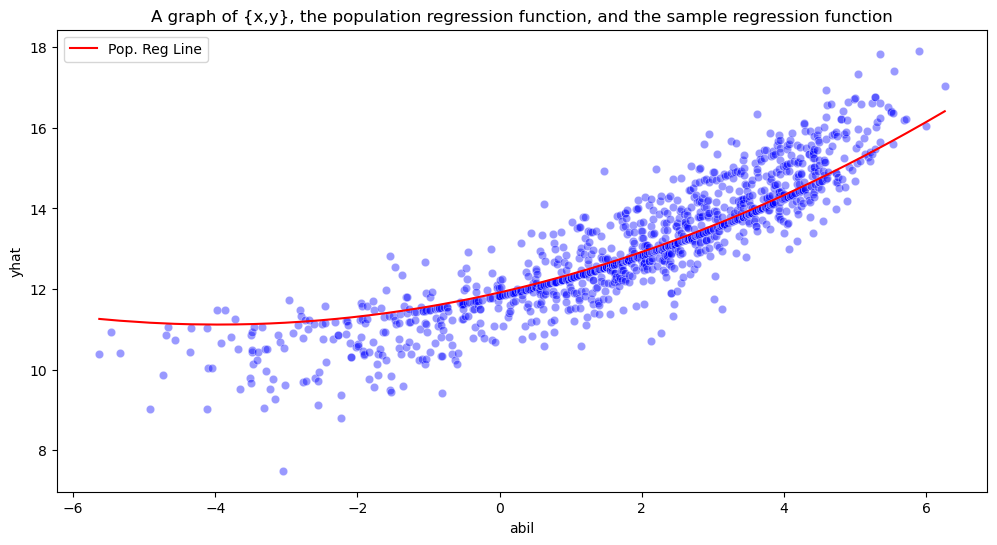

```python
#Set up the objects for our graph:
#Predicted fitted values
htv['yhat'] = m3.fittedvalues

#Residuals
htv['resid'] = m3.resid

# Create a variable 'yaveduc' in your data set that is the estimated y for the average values for education but that still changes with ability.
# Hint retrieve all the parameters and set the linear model equation and construct the regrssion in a similar fashion as (iv)
htv['yaveduc'] = (
    m3.params['Intercept'] +
    m3.params['motheduc'] * 12.18 +
    m3.params['fatheduc'] * 12.45 +
    m3.params['abil'] * htv['abil'] +
    m3.params['abil_squared'] * htv['abil_squared']
)

# You need to sort the values by abil so that the line plots nicely. Try not doing it and see what happens
htv.sort_values(by=['abil'], inplace=True)

# Create the scatter of the abil vs predicted education function, set the title as "log(Salary) vs log(Sales)"
# Hint see how we used sns.regplot in the handout
plt.figure(figsize=(12, 6))
sns.scatterplot(x='abil', y='yhat', data=htv, color='blue', alpha=0.4)
# Add the line that shows the quadratic relation between this two.
# Hint see how we used plt.plot in the handout
plt.plot(htv['abil'], htv['yaveduc'], color='red', label='Pop. Reg Line')
# This code is given to label and produce the graph:
plt.title("A graph of {x,y}, the population regression function, and the sample regression function" )
plt.legend()
plt.show()
```

ECON320 Python Programming Laboratory

Professor *Paloma Lopez de mesa Moyano*

*paloma.moyano@emory.edu*

Department of Economics

Emory University

```python
# convert file into HTML
!jupyter nbconvert --to html E320_Assign3.ipynb
```

[output not shown]

# Econ 320: Python Assignment 3

## Package setup

```python
# Import necessary packages here

import numpy as np
import pandas as pd
import matplotlib.pyplot as plt
import seaborn as sns
import wooldridge as woo
import scipy.stats as stats
from IPython.core.display import HTML
import statsmodels.formula.api as smf
from matplotlib.lines import Line2D
from stargazer.stargazer import Stargazer
from matplotlib.patches import Patch

# Code to print path of current working directory
import os
print(os.getcwd())
```

```
d:\school work\2025 Spring\Econ 320\Econ320Lab\Assignment 3
```

# Question 1

The dataset *ps2q1.dta* contains data on 177 chief executive officers and can be used to examine the effects of firm performance on CEO salary.

i. Estimate a model relating the CEO's annual salary, the dependent variable, to firm sales, the independent variable.

$$salary_i= \beta_0 + \beta_1sales_i +u_i$$

What is your estimate of the intercept and the slope? Don't forget the units, which you can find using the "describe" command. Interpret these estimates, providing an intuitive description that a person who has not taken econometrics can understand. Does your result make economic sense?

```python
data = pd.read_stata("ps2q1.dta")
print(data.info())
```

```
<class 'pandas.core.frame.DataFrame'>
RangeIndex: 177 entries, 0 to 176
Data columns (total 12 columns):
 #   Column    Non-Null Count  Dtype
---  ------    --------------  -----
 0   salary    177 non-null    int16
 1   age       177 non-null    int8
 2   college   177 non-null    int8
 3   grad      177 non-null    int8
 4   comten    177 non-null    int8
 5   ceoten    177 non-null    int8
 6   sales     177 non-null    float32
 7   profits   177 non-null    int16
 8   mktval    177 non-null    float32
 9   comtensq  177 non-null    int16
 10  ceotensq  177 non-null    int16
 11  profmarg  177 non-null    float32
dtypes: float32(3), int16(4), int8(5)
memory usage: 4.5 KB
None
```

salary: Measured in thousands of dollars.  
sales: Measured in millions of dollars.

```python
model = smf.ols(formula='salary ~ sales', data=data).fit()
print(model.summary())
```

```
                            OLS Regression Results
==============================================================================
Dep. Variable:                 salary   R-squared:                       0.438
Model:                            OLS   Adj. R-squared:                  0.435
Method:                 Least Squares   F-statistic:                     136.6
Date:                Sat, 22 Mar 2025   Prob (F-statistic):           1.08e-23
Time:                        18:04:10   Log-Likelihood:                -1456.2
No. Observations:                 177   AIC:                             2916.
Df Residuals:                     175   BIC:                             2923.
Df Model:                           1
Covariance Type:            nonrobust
==============================================================================
                 coef    std err          t      P>|t|      [0.025      0.975]
------------------------------------------------------------------------------
Intercept    474.2893     79.154      5.992      0.000     318.071     630.508
sales          0.1317      0.011     11.687      0.000       0.109       0.154
==============================================================================
Omnibus:                      187.510   Durbin-Watson:                   2.086
Prob(Omnibus):                  0.000   Jarque-Bera (JB):             8601.497
Skew:                           3.774   Prob(JB):                         0.00
Kurtosis:                      36.307   Cond. No.                     8.12e+03
==============================================================================

Notes:
[1] Standard Errors assume that the covariance matrix of the errors is correctly specified.
[2] The condition number is large, 8.12e+03. This might indicate that there are
strong multicollinearity or other numerical problems.
```

ii. Calculate the mean of $salary$ and $sales$. Use these values to prove that the predicted regression line estimated in regression (1) goes through the means of $salary$ and $sales$.

```
          salary      sales
count    177.000    177.000
mean     939.192   3529.463
std     1211.342   6088.654
min      100.000     29.000
25%      471.000    561.000
50%      707.000   1400.000
75%     1119.000   3500.000
max    15000.000  51300.000
Mean of sales: 3529.463
Mean of salary: 939.192
Estimated salary for mean sales: 939.192
Therefore, the averages of salary and sales are on the estimated regression line.
```

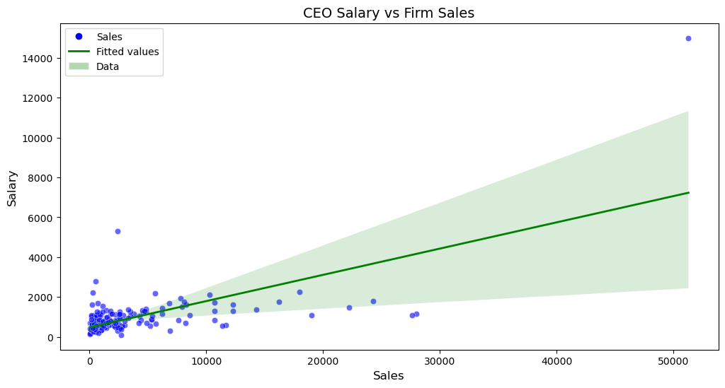

```python
summary_table = data[['salary', 'sales']].describe().round(3)
print(summary_table)
m_salary = data['salary'].mean()
m_sales = data['sales'].mean()
intercept = model.params['Intercept']
slope = model.params['sales']
predicted_salary_at_mean_sales = intercept + slope * m_sales
print(f"Mean of sales: {m_sales:.3f} ")
print(f"Mean of salary: {m_salary:.3f} ")
print(f"Estimated salary for mean sales: {predicted_salary_at_mean_sales:.3f} ")
if round(predicted_salary_at_mean_sales, 3) == round(m_salary, 3):
    print("Therefore, the averages of salary and sales are on the estimated regression line.")
else:
    print("The averages of salary and sales are not on the estimated regression line.")

plt.figure(figsize=(12, 6))
sns.scatterplot(x=data['sales'], y=data['salary'], label="Data", color="blue", alpha=0.6)
sns.regplot(x=data['sales'], y=data['salary'], scatter=False, label="Fitted values", color="green", line_kws={"linewidth": 2}, ci=95)
plt.xlabel("Sales", fontsize=12)
plt.ylabel("Salary", fontsize=12)
plt.title("CEO Salary vs Firm Sales", fontsize=14)
legend_elements = [
    Line2D([0], [0], marker='o', color='w', label='Sales', markerfacecolor='blue', markersize=8),
    Line2D([0], [0], color='green', label='Fitted values', linewidth=2),
    Patch(facecolor='green', edgecolor='w', alpha=0.3, label='Data')
]
plt.legend(handles=legend_elements, loc="upper left")
plt.show()
```

iii. The data entry expert contacts you very concerned about the data they gave you. They realized there was a typo. Replace the value of salary to be 2500 if salary is equal to 15000. Estimate regression (1) with this change. Save the predicted values of salary (). Show a graph with the scatter plot of salary and sales and the predicted regression line of question 1.1 and question 1.4. Discuss these results.

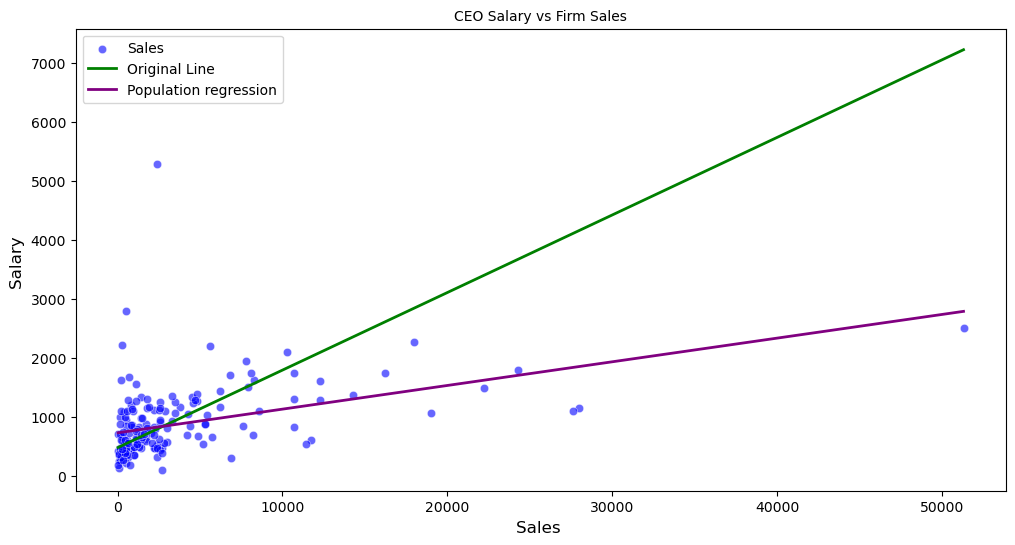

```python
data.loc[data['salary'] == 15000, 'salary'] = 2500
model_corrected = smf.ols(formula='salary ~ sales', data=data).fit()
data['predicted_salary_corrected'] = model_corrected.predict(data)
data['predicted_salary_original'] = model.predict(data)
plt.figure(figsize=(12, 6))
sns.scatterplot(x=data['sales'], y=data['salary'], label="Sales", color="blue", alpha=0.6)
sns.lineplot(x=data['sales'], y=data['predicted_salary_original'], label="Original Line", color="green", linewidth=2)
sns.lineplot(x=data['sales'], y=data['predicted_salary_corrected'], label="Population regression", color="purple", linewidth=2)
plt.xlabel("Sales ", fontsize=12)
plt.ylabel("Salary ", fontsize=12)
plt.title("CEO Salary vs Firm Sales", fontsize=10)
plt.legend()
plt.show()
```

iv. A colleague presented a histogram displaying the distribution of salary and argued that no one could draw any conclusions from a regression using this variable. He correctly points out that regression lines fit through data better when the data is spread across the range of the variable’s possible values. Your colleague wants to use the natural **log of salary** and the natural **log ofbsales** in the model as this function can help to spread out the values of salary and sales. Create the natural logarithm of salary, lnsalary, and the natural logarithm of sales, lnsales. Show the histograms of salary, lnsalary, sales, and lnsales. Discuss whether you think your colleague’s method of spreading the data worked. Estimate the following model:

$lnsalaryi=\gamma_0+\gamma_1lnsalesi+vi$

Then show the regression plot for this new model

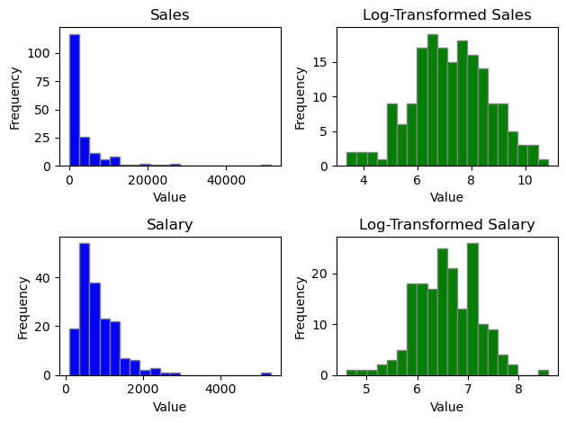

```python
# Create the variables lnsales and lnsalary in the dataset
data['lnsales'] = np.log(data['sales'])
data['lnsalary'] = np.log(data['salary'])

# Fora graph like this you need to create the grid space for plots
#define grid of plots
fig, axs = plt.subplots(nrows=2, ncols=2)

#create histograms
axs[0, 0].hist(data['sales'], edgecolor='gray', bins=20, color='blue')
axs[0, 1].hist(data['lnsales'], edgecolor='gray', bins=20, color='green')
axs[1, 0].hist(data['salary'], edgecolor='gray', bins=20, color='blue')
axs[1, 1].hist(data['lnsalary'], edgecolor='gray', bins=20, color='green')
axs[0, 0].set_title('Sales')
axs[0, 1].set_title('Log-Transformed Sales')
axs[1, 0].set_title('Salary')
axs[1, 1].set_title('Log-Transformed Salary')
for ax in axs.flat:
    ax.set_xlabel('Value')
    ax.set_ylabel('Frequency')


#add title to each histogram
axs[0,0].set_title('Sales');
axs[0,1].set_title('Log-Transformed Sales');

#add title to each histogram
axs[1,0].set_title('Salary');
axs[1,1].set_title('Log-Transformed Salary');

plt.tight_layout()
plt.show()
```

```
                            OLS Regression Results
==============================================================================
Dep. Variable:               lnsalary   R-squared:                       0.284
Model:                            OLS   Adj. R-squared:                  0.280
Method:                 Least Squares   F-statistic:                     69.45
Date:                Sat, 22 Mar 2025   Prob (F-statistic):           2.22e-14
Time:                        18:04:11   Log-Likelihood:                -133.09
No. Observations:                 177   AIC:                             270.2
Df Residuals:                     175   BIC:                             276.5
Df Model:                           1
Covariance Type:            nonrobust
==============================================================================
                 coef    std err          t      P>|t|      [0.025      0.975]
------------------------------------------------------------------------------
Intercept      4.9469      0.200     24.703      0.000       4.552       5.342
lnsales        0.2264      0.027      8.333      0.000       0.173       0.280
==============================================================================
Omnibus:                       12.470   Durbin-Watson:                   2.090
Prob(Omnibus):                  0.002   Jarque-Bera (JB):               33.002
Skew:                           0.060   Prob(JB):                     6.82e-08
Kurtosis:                       5.112   Cond. No.                         38.7
==============================================================================

Notes:
[1] Standard Errors assume that the covariance matrix of the errors is correctly specified.
```

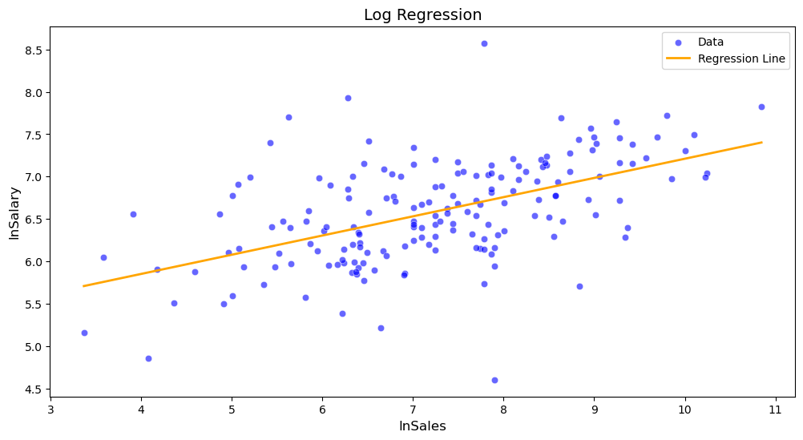

```python
# do the regression plot here.
log_model = smf.ols(formula='lnsalary ~ lnsales', data=data).fit()
print(log_model.summary())
plt.figure(figsize=(12, 6))
sns.scatterplot(x=data['lnsales'], y=data['lnsalary'], label="Data", color="blue", alpha=0.6)
sns.lineplot(x=data['lnsales'], y=log_model.predict(data), label="Regression Line", color="orange", linewidth=2)
plt.xlabel("lnSales", fontsize=12)
plt.ylabel("lnSalary", fontsize=12)
plt.title("Log Regression", fontsize=14)
plt.legend()
plt.show()
```

# Question 2

Use the dataset ATTEND for this exercise, and the handouts to work on these questions. Wooldridge data sets here: http://fmwww.bc.edu/ec-p/data/wooldridge/datasets.list.html

i. Generate a table that shows the minimum, maximum, and average values for the following variables in the attend dataset:  
Percent classes attended  
Cumulative GPA prior to term  
ACT score  
Using two different methods. Round off all calculations to 3 decimal points. (Refer to week 3 module)

```python
# Load dataset attend from wooldridge, call it attend.
attend = woo.data('attend')
# Method 1: Use .agg() to calculate, call it tablestats.
columns = ['atndrte', 'priGPA', 'ACT']
t = attend[columns].agg(['mean', 'min', 'max']).round(3)
print("Table using .agg():")
print(t)
```

```
Table using .agg():
      atndrte  priGPA    ACT
mean    81.71   2.587  22.51
min      6.25   0.857  13.00
max    100.00   3.930  32.00
```

```python
# Method 2: Use .describe() to calculate.
t2 = attend[columns].describe().round(3)
print("Table using .describe():")
print(t2)
```

```
Table using .describe():
       atndrte   priGPA      ACT
count  680.000  680.000  680.000
mean    81.710    2.587   22.510
std     17.047    0.545    3.491
min      6.250    0.857   13.000
25%     75.000    2.190   20.000
50%     87.500    2.560   22.000
75%     93.750    2.943   25.000
max    100.000    3.930   32.000
```

ii. Estimate the following model:

$$atndrte = \beta_0 + \beta_1 priGPA + \beta_2 ACT + u$$

Show results in an stargazer table. (Refer to output presentation handout)

```python
# Estimate log-level model, call it mc4.
# Fit your regression using .fit().
# Print results using summary:
mc4 = smf.ols(formula='atndrte ~ priGPA + ACT', data=attend).fit()
st = Stargazer([mc4])
HTML(st.render_html())
```

|  | *Dependent variable: atndrte* |
| --- | --- |
|  | (1) |
| ACT | -1.717*** |
|  | (0.169) |
| Intercept | 75.700*** |
|  | (3.884) |
| priGPA | 17.261*** |
|  | (1.083) |
| Observations | 680 |
| R<sup>2</sup> | 0.291 |
| Adjusted R<sup>2</sup> | 0.288 |
| Residual Std. Error | 14.379 (df=677) |
| F Statistic | 138.651*** (df=2; 677) |
| Note: | *p<0.1; **p<0.05; ***p<0.01 |

iii. Calculate and print the average of predicted value of percent classes attended ( $\hat{atndrte}$ ) and the predicted value. Round to 5 decimal points and compare results. (Refer to week 5 module)

> Note that these two are different coding-wise. The first method is the mean of the prediction, and the second is the prediction of the mean

```python
attend['predicted_atndrte'] = mc4.predict(attend)
# Print the mean of the prediction
m_predicted = attend['predicted_atndrte'].mean()
print(f"Model1 \n Average predicted attendance rate is \n mean of yhat= {m_predicted:.5f}")
# Find the prediction of the mean
m_priGPA = attend['priGPA'].mean()
m_ACT = attend['ACT'].mean()
predicted_mean = mc4.params['Intercept'] + mc4.params['priGPA'] * m_priGPA + mc4.params['ACT'] * m_ACT
# Print the prediction of the mean
print(f"Model1 \n Predicted attendance rate for average GPA and ACT is \n yhat of mean x=  {predicted_mean:.5f}")
```

```
Model1
 Average predicted attendance rate is
 mean of yhat= 81.70956
Model1
 Predicted attendance rate for average GPA and ACT is
 yhat of mean x=  81.70956
```

We can observe that these 2 values are the same :)!

iv. What is the predicted `atndrte` if `priGPA`= 3.65 and `ACT`= 20? What is the predicted difference in attendance rates between this and the the average $\hat{atndrte}$ above? (Refer to week 3 and 4 module)

In this case, do not use the `.predict()` function for your code. Instead, retrieve the coeffients and calculate the equation.
$$atndrte = \hat\beta_0 + \hat\beta_1 3.65 + \hat\beta_2 20 + u$$

```python
# Calculate the mean of the prediction, call this yhat1.
yhat1 = attend['predicted_atndrte'].mean()
# Calculate predicted atndrte for 3.65 GPA and 20 ACT using the above equation, call this yhat2.
yhat2 = mc4.params['Intercept'] + mc4.params['priGPA'] * 3.65 + mc4.params['ACT'] * 20
# Print yhat2 and round to 3 decimal places, call this yhat.
print(f"yhat = {yhat2:.3f}")
# Print the difference between yhat2 and yhat1, call this difference.
difference = yhat2 - yhat1
print(f"Difference = {difference:.3f}")
```

```
yhat = 104.371
Difference = 22.661
```

v. Run two more models: one only for freshmen and another only for sophomores. Save the results in objects `mfre` and `msoph` respectively  
*Hint: the data argument now has a restriction*  
Freshmen : `attend['frosh']==1`  
Sophomores : `attend['soph']==1`

```python
# compute OLS only for freshmen
freshmen = attend[attend['frosh'] == 1]
mfre = smf.ols(formula='atndrte ~ priGPA + ACT', data=freshmen).fit()
# compute OLS only for sophomores
sophomore = attend[attend['soph'] == 1]
msoph = smf.ols(formula='atndrte ~ priGPA + ACT', data=sophomore).fit()
```

vi. Show your results in a table:

Create one table comparing the parameters from the three models and another table comparing $R^2$ and the number of observations. Label the results with all students "All", data with just freshmen "Freshmen", and data with just sophomores "Sophomore". Round all values to 4 decimal places. (Refer to week 3 module)

The table below compares $\beta's$

```python
# Create a table to examine the parameters, call this table.

# Table formatting is given to you

table = pd.DataFrame({
    'All': mc4.params,
    'Freshmen': mfre.params,
    'Sophomore': msoph.params
}).round(3)
print("Table comparing parameters (β's):")
print(table)

#table.style.format('{:,.3f}'.format)
table = table.style.format('{:,.3f}')
```

```
Table comparing parameters (β's):
              All  Freshmen  Sophomore
Intercept  75.700    76.507     74.887
priGPA     17.261    16.062     18.869
ACT        -1.717    -1.487     -1.898
```

The table below compares the $R^2$ and observations for the models estimated. $\textbf{HINT:}$ If you are stuck, look up how to use the index options.

```python
table2 = pd.DataFrame({
    'All': {'R^2': mc4.rsquared, 'Observations': mc4.nobs},
    'Freshmen': {'R^2': mfre.rsquared, 'Observations': mfre.nobs},
    'Sophomore': {'R^2': msoph.rsquared, 'Observations': msoph.nobs}
}).round(3)
print("\nTable comparing R^2 and observations for the model estimated:")
print(table2)
table2 = table2.style.format('{:,.3f}')
```

```
Table comparing R^2 and observations for the model estimated:
                  All  Freshmen  Sophomore
R^2             0.291     0.286       0.32
Observations  680.000   158.000     392.00
```

vii. Calculate the correlation between the residuals and the `priGPA` for the first model. This is similar to how we showed that mean of residuals is equal to zero (Refer to week 3 and module).

```python
# Calculate the residuals from the first model, call this u_hat.
attend['u_hat'] = mc4.resid
# Calculate the correlation between the residuals and priGPA, call this corrx_u_hat. Round to 3 decimal places.
corrx_u_hat = attend['u_hat'].corr(attend['priGPA']).round(3)
# Remember this accesses the first element of the correlation matrix

# Printing is given to you:
print(f'Corr GPA and residuals:  \n', abs(corrx_u_hat))
# this number approximates to zero from the left hand side
# so we use the absolute value so that it doesn't have a negative sign
```

```
Corr GPA and residuals:
 0.0
```

vi. Present all results form the three models in an stargazer table Change the order of the covariates and add name to the columns

```python
# print results using summary:
st = Stargazer([mc4, mfre, msoph])
st.covariate_order(['priGPA', 'ACT', 'Intercept'])
st.custom_columns(['All Students', 'Freshmen', 'Sophomores'], [1, 1, 1])
HTML(st.render_html())
```

|  | *Dependent variable: atndrte* |  |  |
| --- | --- | --- | --- |
|  | All Students | Freshmen | Sophomores |
|  | (1) | (2) | (3) |
| priGPA | 17.261*** | 16.062*** | 18.869*** |
|  | (1.083) | (2.362) | (1.440) |
| ACT | -1.717*** | -1.487*** | -1.898*** |
|  | (0.169) | (0.331) | (0.227) |
| Intercept | 75.700*** | 76.507*** | 74.887*** |
|  | (3.884) | (8.679) | (5.113) |
| Observations | 680 | 158 | 392 |
| R<sup>2</sup> | 0.291 | 0.286 | 0.320 |
| Adjusted R<sup>2</sup> | 0.288 | 0.277 | 0.316 |
| Residual Std. Error | 14.379 (df=677) | 14.029 (df=155) | 14.157 (df=389) |
| F Statistic | 138.651*** (df=2; 677) | 31.106*** (df=2; 155) | 91.510*** (df=2; 389) |
| Note: | *p<0.1; **p<0.05; ***p<0.01 |  |  |

# From Computer Exercise 10

Use the data in Wooldridge's HTV to answer this question. The data set includes information on wages, education, parents’ education, and several other variables for 1,230 working men in 1991.

i. Investigate some descriptive statistics

- What is the range of the `educ` variable in the sample?

```python
# Load the dataset, call it htv.
htv = woo.data('htv')
# Find some descriptive statistics of the education variable, use des.()
print(htv['educ'].describe())
# Summary provides the mean and max of the variable - therefore the range
educ_range = htv['educ'].describe()['max'] - htv['educ'].describe()['min']
print(f"Range of 'educ': {educ_range}")
```

```
count    1230.000000
mean       13.037398
std         2.354346
min         6.000000
25%        12.000000
50%        12.000000
75%        15.000000
max        20.000000
Name: educ, dtype: float64
Range of 'educ': 14.0
```

- What percentage of men completed twelveth grade but no higher grade?

  > Hint: use a logical expression and calculate the mean
- Do the men or their parents have, on average, higher levels of education?

```python
# Calculate the percentage of men that did not complete more than high school, print this as Percentage of men with HS.
HS = (htv['educ'] == 12).mean()
print(f"Percentage of men with HS= {HS:.3f}")
```

```
Percentage of men with HS= 0.416
```

```python
# Create a table with average education for the men, their mothers, and their fathers, call this table p.
m_educ = htv['educ'].mean()
m_motheduc = htv['motheduc'].mean()
m_fatheduc = htv['fatheduc'].mean()
p = pd.DataFrame({
    "Averages": [m_educ, m_motheduc, m_fatheduc]
}, index=["Men's education", "Mother's education", "Father's education"])
# The given code below will print the table.
pd.DataFrame(round(p,3), columns=["Averages"])
```

|  | Averages |
| --- | --- |
| Men's education | 13.037 |
| Mother's education | 12.178 |
| Father's education | 12.447 |

Men have higher level of education compare to their parents

ii. Estimate the regression model
$$ educ = \beta_0 + \beta_1 \cdot motheduc + \beta_2 \cdot fatheduc + u $$ by OLS and report the results in the usual form.

How much sample variation in `educ` is explained by parents’ education? Think about the interpretation of the coefficient on `motheduc`.

```python
# Print the regression results
model1 = smf.ols(formula='educ ~ motheduc + fatheduc', data=htv).fit()
print(model1.summary())
```

```
                            OLS Regression Results
==============================================================================
Dep. Variable:                   educ   R-squared:                       0.249
Model:                            OLS   Adj. R-squared:                  0.248
Method:                 Least Squares   F-statistic:                     203.7
Date:                Sat, 22 Mar 2025   Prob (F-statistic):           4.13e-77
Time:                        18:04:11   Log-Likelihood:                -2621.7
No. Observations:                1230   AIC:                             5249.
Df Residuals:                    1227   BIC:                             5265.
Df Model:                           2
Covariance Type:            nonrobust
==============================================================================
                 coef    std err          t      P>|t|      [0.025      0.975]
------------------------------------------------------------------------------
Intercept      6.9644      0.320     21.776      0.000       6.337       7.592
motheduc       0.3042      0.032      9.528      0.000       0.242       0.367
fatheduc       0.1903      0.022      8.539      0.000       0.147       0.234
==============================================================================
Omnibus:                       60.519   Durbin-Watson:                   1.748
Prob(Omnibus):                  0.000   Jarque-Bera (JB):               82.103
Skew:                           0.455   Prob(JB):                     1.48e-18
Kurtosis:                       3.879   Cond. No.                         98.0
==============================================================================

Notes:
[1] Standard Errors assume that the covariance matrix of the errors is correctly specified.
```

Parents' education explains 24.9% of the variation in children's education, as indicated by the R-squared value of 0.249. The coefficient on motheduc is 0.304, meaning that for every additional year of a mother's education, the child's education increases by 0.304 years, holding the father's education constant.The coefficient on fatheduc is 0.190, meaning that for every additional year of a father's education, the child's education increases by 0.190 years, holding the mother's education constant.

iii. Add the variable `abil` (a measure of cognitive ability) to the regression from part (ii), and report the results in equation form. Does “ability” help to explain variations in education, even after controlling for parents’ education? Explain.

```python
# Print the new ols regressions results
model2 = smf.ols(formula='educ ~ motheduc + fatheduc + abil', data=htv).fit()
print(model2.summary())
```

```
                            OLS Regression Results
==============================================================================
Dep. Variable:                   educ   R-squared:                       0.428
Model:                            OLS   Adj. R-squared:                  0.426
Method:                 Least Squares   F-statistic:                     305.2
Date:                Sat, 22 Mar 2025   Prob (F-statistic):          5.95e-148
Time:                        18:04:11   Log-Likelihood:                -2455.0
No. Observations:                1230   AIC:                             4918.
Df Residuals:                    1226   BIC:                             4938.
Df Model:                           3
Covariance Type:            nonrobust
==============================================================================
                 coef    std err          t      P>|t|      [0.025      0.975]
------------------------------------------------------------------------------
Intercept      8.4487      0.290     29.180      0.000       7.881       9.017
motheduc       0.1891      0.029      6.635      0.000       0.133       0.245
fatheduc       0.1111      0.020      5.586      0.000       0.072       0.150
abil           0.5025      0.026     19.538      0.000       0.452       0.553
==============================================================================
Omnibus:                       52.055   Durbin-Watson:                   1.821
Prob(Omnibus):                  0.000   Jarque-Bera (JB):               61.086
Skew:                           0.465   Prob(JB):                     5.44e-14
Kurtosis:                       3.570   Cond. No.                         102.
==============================================================================

Notes:
[1] Standard Errors assume that the covariance matrix of the errors is correctly specified.
```

Based on the result, `abil`(ability) do help. Because , its coefficient is 0.5025 and highly statistically significant by the fact its p-value is zero, which means it is statiscally significant. This indicates that individuals with higher cognitive ability tend to achieve higher levels of education, even after controlling for parents' education.

iv. Now estimate an equation where `abil` appears in quadratic form

```python
# Add in abil squared using numpy and fit the model, call this m3.
htv['abil_squared'] = np.power(htv['abil'], 2)
m3 = smf.ols(formula='educ ~ motheduc + fatheduc + abil + abil_squared', data=htv).fit()
# Print the regression results using .summary()
print(m3.summary())
```

```
                            OLS Regression Results
==============================================================================
Dep. Variable:                   educ   R-squared:                       0.444
Model:                            OLS   Adj. R-squared:                  0.443
Method:                 Least Squares   F-statistic:                     244.9
Date:                Sat, 22 Mar 2025   Prob (F-statistic):          1.34e-154
Time:                        18:04:11   Log-Likelihood:                -2436.6
No. Observations:                1230   AIC:                             4883.
Df Residuals:                    1225   BIC:                             4909.
Df Model:                           4
Covariance Type:            nonrobust
================================================================================
                   coef    std err          t      P>|t|      [0.025      0.975]
--------------------------------------------------------------------------------
Intercept        8.2402      0.287     28.671      0.000       7.676       8.804
motheduc         0.1901      0.028      6.767      0.000       0.135       0.245
fatheduc         0.1089      0.020      5.558      0.000       0.070       0.147
abil             0.4015      0.030     13.255      0.000       0.342       0.461
abil_squared     0.0506      0.008      6.093      0.000       0.034       0.067
==============================================================================
Omnibus:                       45.933   Durbin-Watson:                   1.820
Prob(Omnibus):                  0.000   Jarque-Bera (JB):               56.769
Skew:                           0.404   Prob(JB):                     4.71e-13
Kurtosis:                       3.674   Cond. No.                         115.
==============================================================================

Notes:
[1] Standard Errors assume that the covariance matrix of the errors is correctly specified.
```

v. Use the estimates in part (iv) to graph the relationship between the predicted `education` and `abil`. Set `motheduc` and `fatheduc` at their average values in the sample, 12.18 and 12.45, respectively. See handout for more. (Refer to week 4 module)

```python
# look at the coeficients
print(pd.DataFrame(m3.params,columns=['Coefficients']))
```

```
              Coefficients
Intercept         8.240226
motheduc          0.190126
fatheduc          0.108939
abil              0.401462
abil_squared      0.050599
```

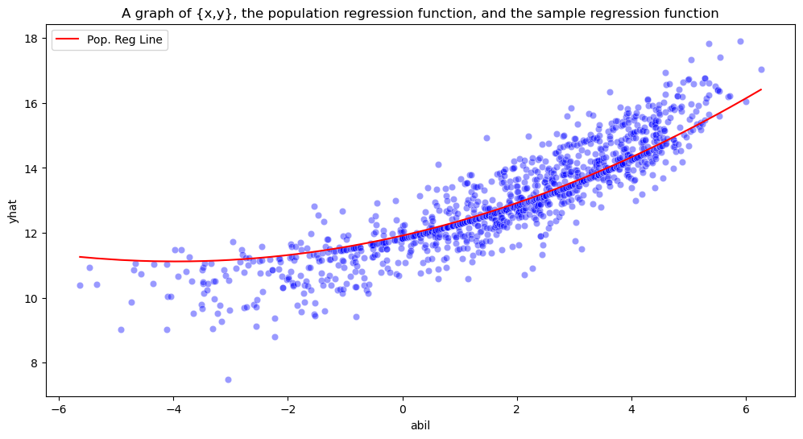

```python
#Set up the objects for our graph:
#Predicted fitted values
htv['yhat'] = m3.fittedvalues

#Residuals
htv['resid'] = m3.resid

# Create a variable 'yaveduc' in your data set that is the estimated y for the average values for education but that still changes with ability.
# Hint retrieve all the parameters and set the linear model equation and construct the regrssion in a similar fashion as (iv)
htv['yaveduc'] = (
    m3.params['Intercept'] +
    m3.params['motheduc'] * 12.18 +
    m3.params['fatheduc'] * 12.45 +
    m3.params['abil'] * htv['abil'] +
    m3.params['abil_squared'] * htv['abil_squared']
)

# You need to sort the values by abil so that the line plots nicely. Try not doing it and see what happens
htv.sort_values(by=['abil'], inplace=True)

# Create the scatter of the abil vs predicted education function, set the title as "log(Salary) vs log(Sales)"
# Hint see how we used sns.regplot in the handout
plt.figure(figsize=(12, 6))
sns.scatterplot(x='abil', y='yhat', data=htv, color='blue', alpha=0.4)
# Add the line that shows the quadratic relation between this two.
# Hint see how we used plt.plot in the handout
plt.plot(htv['abil'], htv['yaveduc'], color='red', label='Pop. Reg Line')
# This code is given to label and produce the graph:
plt.title("A graph of {x,y}, the population regression function, and the sample regression function" )
plt.legend()
plt.show()
```

ECON320 Python Programming Laboratory

Professor *Paloma Lopez de mesa Moyano*

*paloma.moyano@emory.edu*

Department of Economics

Emory University

```python
# convert file into HTML
!jupyter nbconvert --to html E320_Assign3.ipynb
```

[output not shown]